# super-fx

Knott, Z., Nydam, A., Bowman, H., Dux, PE., & Garner, KG.

2021-01-12 13:35:14

# Introduction

# Methods

### Simulation protocol

Extra simulations were each run with an extra error term for the T1 or T2 stimulus (AB and SD), for experimentor ID, or for task-order, but the results suggested that the addition of an extra random effect resulted in a model structure that was too complex for the data.

### Model definitions

RFX: e.g. AB
$$y_{ij} \sim lag + e_{i} + e_{ij}$$
Tested for significance by performing the likelihood ratio test between the model containing the effect of interest and the null model (see each task for definitions).

[Will prob move the below to the relevant section in the results] #### Attentional Blink

*FFX*: A repeated-measures ANOVA with one factor (lag: 2, 3, 5 & 7) was performed. Cohen’s $d$ is reported for the main effect of lag. *RFX*: For the RFX analysis we included an extra intercept term for each subject. Again, Cohen’s $d$ is reported for the main effect of lag. To test for the statistical significance of the main effect of lag, the RFX model containing the lag term was compared to the model containing the subject and error intercepts.

#### Dual-task

*FFX*: Data were modelled using a 2 (modality: visual vs auditory) x 2 (task: single vs dual) repeated-measures ANOVA. Cohen’s $d$ is reported for the main effect of task. *RFX*: The RFX model of interest contained an additional intercept term for each subject. To test for the statistical significance of the main effect of task, the model of interest was compared to a null model that contained only the regressor for modality, and the subject and error intercepts.

#### Contextual Cueing

*FFX*: A block (1:12) x condition (repeat vs novel) repeated-measures ANOVA was applied to the data. Cohen’s $d$ is reported for the block x condition interaction. *RFX*: An additional intercept term for each subject was added to the main model of interest. To test for statistical significance of the block x condition interaction, the model of interest was compared to a null model that contained only regressors for the main effect of block, the main effect of task, and the subject intercept terms.

#### Serial Response Task

*FFX*: For the SRT data, mean RTs from repeat and novel sequences were compared using a within-subjects t-test. *RFX*: A linear mixed effects model with a regressor for condition (repeat vs novel) and a subject intercept term was compared to a null model that contained only the subject intercept term.

## Results

### Attentional Blink

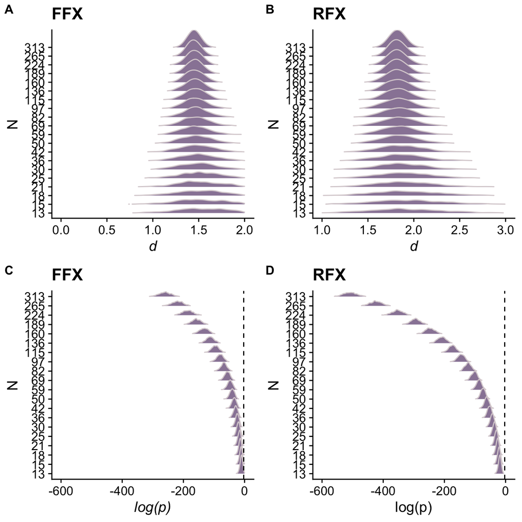

AB simulation results. A) showing Cohen’s {d} attained for each sample size for the FFX modelling for the main effect of lag, B) showing Cohen’s $d$ attained from the RFX modelling of lag + subject intercept, C) showing the log p-values attained across simulations at each sample size N for the FFX model, the vertical dashed line shows log(p=.05). Note: all p-values to the left of this line would result in a rejection of the null hypothesis. D) same as C, except for the RFX model.

Notes: large Cohen’s $d$, it looks like RFX modelling suggests a larger range of effect sizes for smaller sample sizes, but that this issue goes away as the precision capacity of the estimate increases. For FFX, sample sizes > 18 ensure the alternate will not be rejected, whereas for RFX, all exp sizes = reject null.

Idea: ratio of range of d-values for each model/N?

### Dual-task

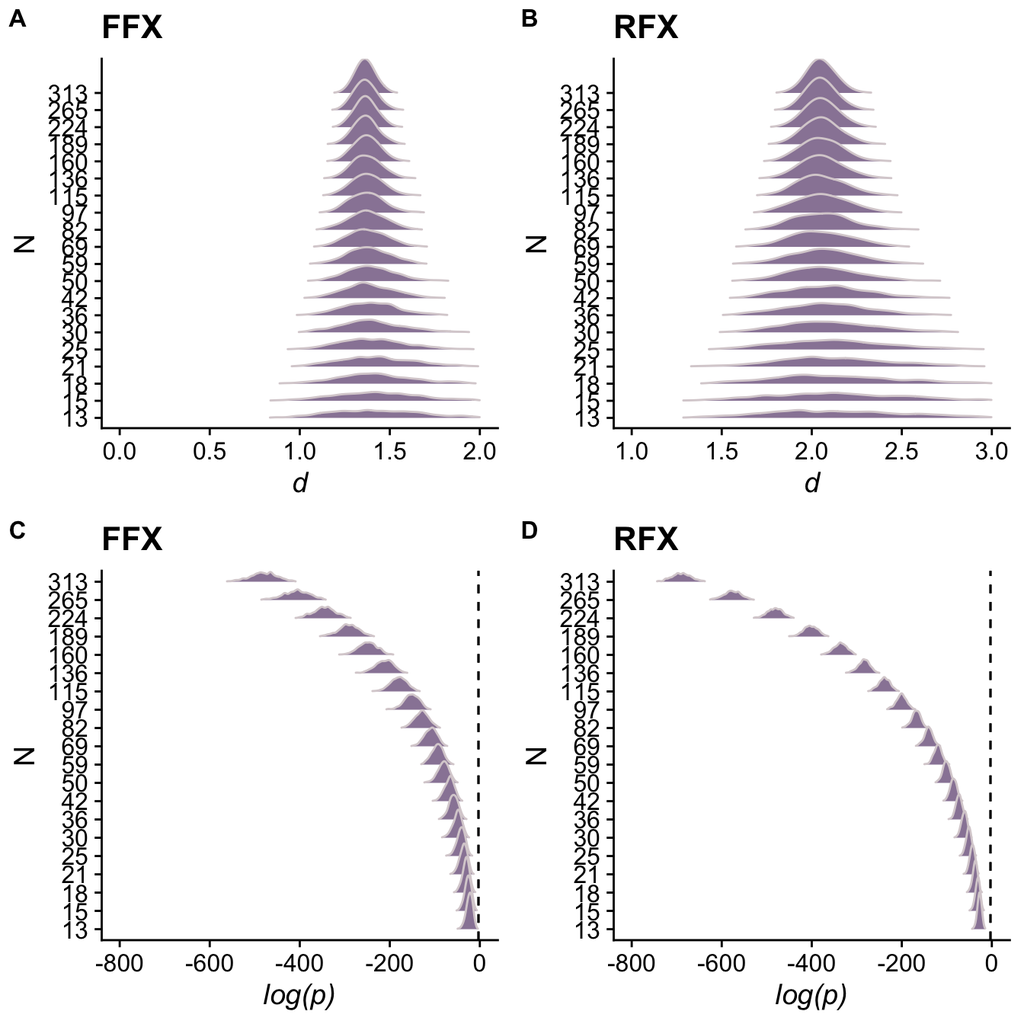

Dual-task simulation results. A) showing Cohen’s {d} attained for each sample size for the FFX modelling for the main effect of task (single vs dual), B) showing Cohen’s $d$ attained from the RFX modelling with an additional subject intercept, C) showing the log p-values attained across simulations at each sample size N for the FFX model, the vertical dashed line shows log(p=.05). D) same as C, except for the RFX model.

All is a similar story to the AB

### Contextual Cueing

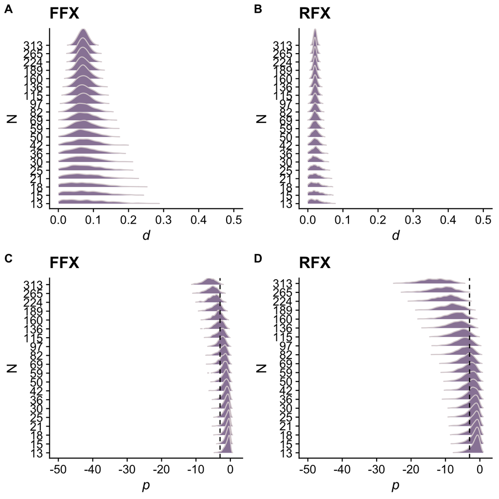

Contextual-cueing simulation results. A) showing Cohen’s {d} attained for each sample size for the FFX modelling for the interaction of block x condition (repeat vs novel), B) showing Cohen’s $d$ attained from the RFX modelling with an additional subject intercept, C) showing the log p-values attained across simulations at each sample size N for the FFX model, the vertical dashed line shows log(p=.05). D) same as C, except for the RFX model.

Putative reason for differences in effect size observations between FFX and RFX: FFX models deviations from the grand mean - therefore a subject that shows a large deviation from the grand mean can inflate the variance soaked up by the condition regressor. As the RFX model includes a subject intercept, the regressor of interest can only soak up the variance of interest.

Q: are large effect size observations driven by individuals who are far from the grand mean?

- note from Chris: plot effect size vs p
- also, can you get sig with consistent d=.05 across subs?

One clue towards these thoughts would be if the subject intercept estimates showed, on some simulations, larger values than on other simulations - i.e. the distribution should be skewed or bimodal.

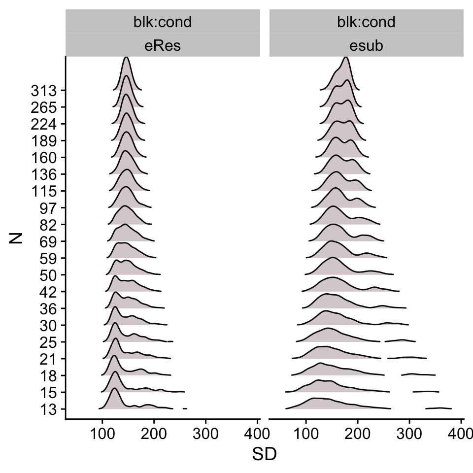

Estimates of the residual and subject intercept terms from the Contextual-cueing RFX simulations. A) showing standard deviations of the estimated Residual error distribution, B) the standard deviations for the subject intercept distribution.

### Serial Response Task

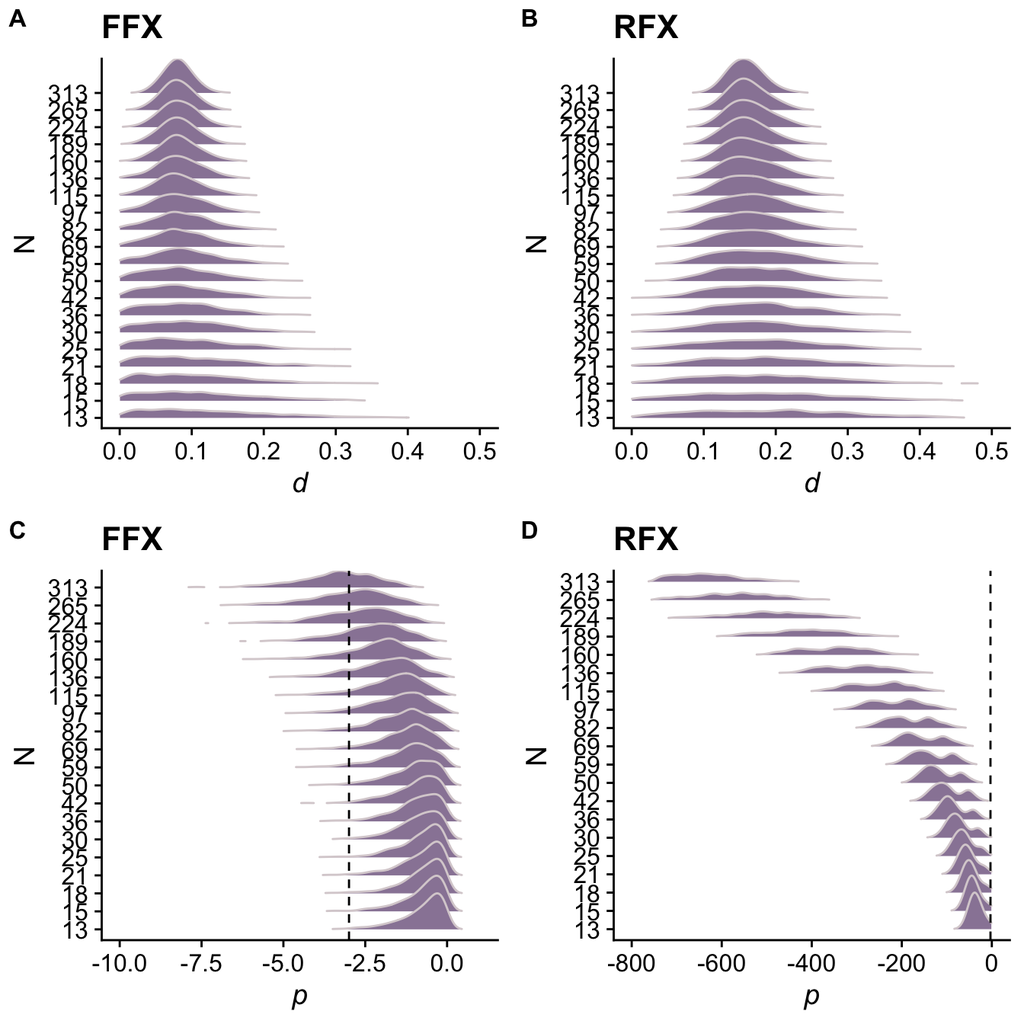

Serial Response Task simulation results. A) showing Cohen’s {d} attained for each sample size for the FFX modelling, using a within-subjects t-test to compare condition (repeat vs novel), B) showing Cohen’s $d$ attained from the RFX modelling with an additional subject intercept, C) showing the log p-values attained across simulations at each sample size N for the FFX model, the vertical dashed line shows log(p=.05). D) same as C, except for the RFX model.

Note: FFX leads you awry far more often than RFX Modelling subject means is important for implicit learning tasks.

### Visual Statistical Learning